# Part I - (Loan Data from Prosper)

### What is the structure of your dataset?

After wrangling, the data set contains 33,930 loans from July 2009 and 16 select variables on each loan, including;

Listing Number - The number that uniquely identifies the listing to the public as displayed on the website.

Listing Creation Date - The date the listing was created.

LoanStatus - The current status of the loan: Cancelled, Chargedoff, Completed, Current, Defaulted, FinalPaymentInProgress, PastDue. The PastDue status will be accompanied by a delinquency bucket.

ProsperScore - A custom risk score built using historical Prosper data. The score ranges from 1-11, with 11 being the best, or lowest risk score. Applicable for loans originated after July 2009.

ListingCategory (numeric) - The category of the listing that the borrower selected when posting their listing: 0 - Not Available, 1 - Debt Consolidation, 2 - Home Improvement, 3 - Business, 4 - Personal Loan, 5 - Student Use, 6 - Auto, 7- Other, 8 - Baby&Adoption, 9 - Boat, 10 - Cosmetic Procedure, 11 - Engagement Ring, 12 - Green Loans, 13 - Household Expenses, 14 - Large Purchases, 15 - Medical/Dental, 16 - Motorcycle, 17 - RV, 18 - Taxes, 19 - Vacation, 20 - Wedding Loans

BorrowerState - The two letter abbreviation of the state of the address of the borrower at the time the Listing was created.

EmploymentStatus - The employment status of the borrower at the time they posted the listing.

EmploymentStatusDuration - The length in months of the employment status at the time the listing was created.

IsBorrowerHomeowner - A Borrower will be classified as a homowner if they have a mortgage on their credit profile or provide documentation confirming they are a homeowner.

CreditScoreRangeLower - The lower value representing the range of the borrower's credit score as provided by a consumer credit rating agency.

CreditScoreRangeUpper - The upper value representing the range of the borrower's credit score as provided by a consumer credit rating agency.

Available Bank card Credit - The total available credit via bank card at the time the credit profile was pulled.

Stated Monthly Income -The monthly income the borrower stated at the time the listing was created.

Loan Original Amount - The origination amount of the loan.

Loan Origination Quarter - The quarter in which the loan was originated.

Monthly Loan Payment - The scheduled monthly loan payment.

### What is/are the main feature(s) of interest in your dataset?

The main feature of interest is the LoanStatus. I am looking to see how select variables affect a loan’s outcome status.

### What features in the dataset do you think will help support your investigation into your feature(s) of interest?

Some of the select variables I think would help with this investigation include; 1) LoanStatus 2) ProsperScore 3) ListingCategory (numeric) 4) BorrowerState 5) EmploymentStatus 6) EmploymentStatusDuration 7) IsBorrowerHomeowner 8) CreditScoreRangeLower 9) CreditScoreRangeUpper 10) AvailableBankcardCredit 11) StatedMonthlyIncome 12) LoanOriginalAmount 13) LoanOriginationQuarter 14) MonthlyLoanPayment

## Univariate Exploration

### Question

To start with the investigation, what does the distribution of all the select interest variables look like?, going numerically as follows : 1) LoanStatus 2) ProsperScore 3) ListingCategory (numeric) 4) BorrowerState 5) EmploymentStatus 6) EmploymentStatusDuration 7) IsBorrowerHomeowner 8) CreditScoreRangeLower 9) CreditScoreRangeUpper 10) AvailableBankcardCredit 11) StatedMonthlyIncome 12) LoanOriginalAmount 13) LoanOriginationQuarter 14) MonthlyLoanPayment

### Visualisation 1

```
Text(0.5,0,'Count')
```

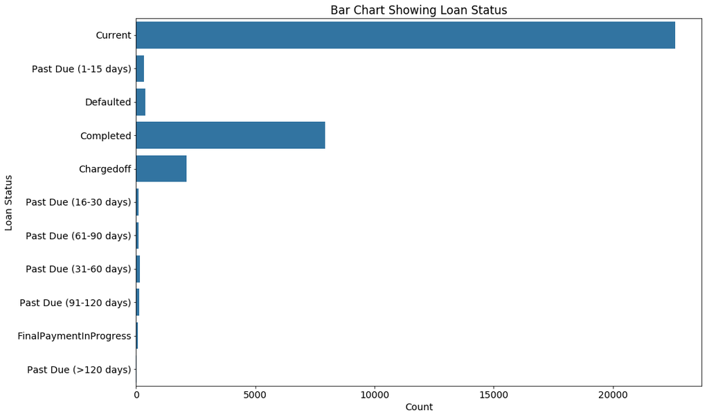

```python
base_color = sb.color_palette()[0]
plt.rcParams ['figure.figsize'] = (15,10)
plt.rcParams.update({'font.size': 14})
sb.countplot(data=loan, y='LoanStatus', color=base_color);

# Labeling the axes
plt.title ('Bar Chart Showing Loan Status')
plt.ylabel('Loan Status')
plt.xlabel('Count')
```

```python
loan.LoanStatus.value_counts ()
```

```
Current                   22605
Completed                  7938
Chargedoff                 2102
Defaulted                   393
Past Due (1-15 days)        314
Past Due (31-60 days)       159
Past Due (91-120 days)      118
Past Due (61-90 days)       110
Past Due (16-30 days)        97
FinalPaymentInProgress       86
Past Due (>120 days)          8
Name: LoanStatus, dtype: int64
```

### Observation 1

> ● More than half of the listings fall under the category 'current' ● There is are substantial amount of listings under completed, chargedoff, defaulted and past due (1-15 days)

### Visualisation 2

```python
#changing prosper score datatype from float to int
loan.ProsperScore = loan.ProsperScore.astype ('int')
```

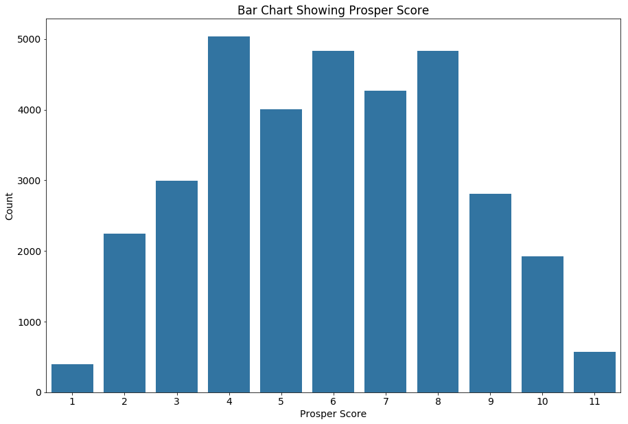

```python
sb.countplot(data=loan, x='ProsperScore', color=base_color);

# Labeling the axes
plt.title ('Bar Chart Showing Prosper Score')
plt.xlabel('Prosper Score')
plt.ylabel('Count')

# Dsiplay the plot
plt.show()
```

### Visualisation 3

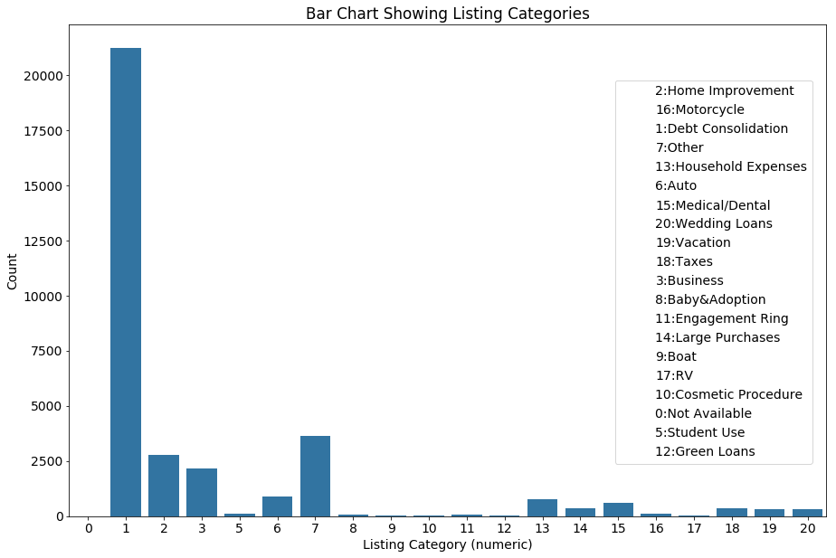

```python
#creating a dictionary to hold the listing categories
data_dic={0:'0:Not Available', 1:'1:Debt Consolidation', 2:'2:Home Improvement',
          3:'3:Business', 4:'4:Personal Loan', 5:'5:Student Use', 6:'6:Auto', 7:'7:Other',
          8:'8:Baby&Adoption', 9:'9:Boat', 10:'10:Cosmetic Procedure',11:'11:Engagement Ring',
          12:'12:Green Loans', 13:'13:Household Expenses', 14:'14:Large Purchases',
          15:'15:Medical/Dental', 16:'16:Motorcycle', 17:'17:RV', 18:'18:Taxes',
          19:'19:Vacation', 20:'20:Wedding Loans' }

xval= loan['ListingCategory (numeric)'].unique ()
yval= loan['ListingCategory (numeric)'].value_counts ()


#using a for loop to iterate through the dictionary and display it as a legend
for j in range(len(xval)):
    sb.countplot(data=loan, x='ListingCategory (numeric)', color=base_color);
    plt.plot(1,1,label = data_dic[xval[j]], marker = '', ls = '')



#labelling the axes
plt.legend(frameon=True, bbox_to_anchor = (0.99, 0.9))
plt.title ('Bar Chart Showing Listing Categories')
plt.xlabel('Listing Category (numeric)')
plt.ylabel('Count')

# Dsiplay the plot
plt.show()
```

### Observation 3

● The most popular category among the listings is one, meaning most people take loans for debt consolidation.

● The next being 7 (other), 2 (home improvement), 3 (business), 6 (auto), 13 (household expenses), 15 (medical/dental), 14 (large purchases), 18 (taxes), 19 (vacation), 20 (wedding loans), 16 (motorcycle).

● While, 17 (RV), 8 (baby and adoption), 9 (boat), 10 (cosmetic procedure), 11 (engagement ring), 12 (green loans), 0 (not available) are the least popular categories.

● There was no listing under the category 4 (personal loan).

### Visualisation 4

```
Text(0,0.5,'Count')
```

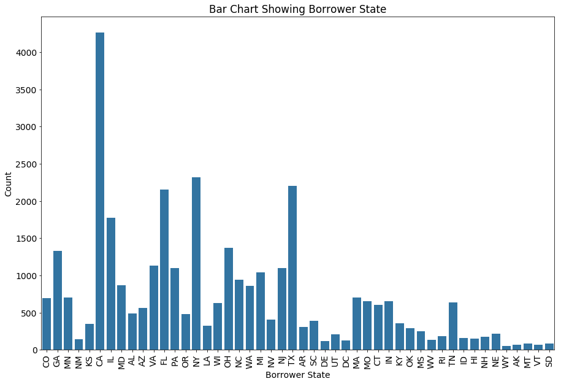

```python
sb.countplot(data=loan, x='BorrowerState', color=base_color);
plt.xticks(rotation=90)
#Labeling the axes
plt.title ('Bar Chart Showing Borrower State')
plt.xlabel('Borrower State')
plt.ylabel('Count')
```

### Observation 4

● The state with the most amount of borrowers is California with over 4000 listings and Wyoming has the least with less than a 100.

### Visualisation 5

```
Text(0,0.5,'Count')
```

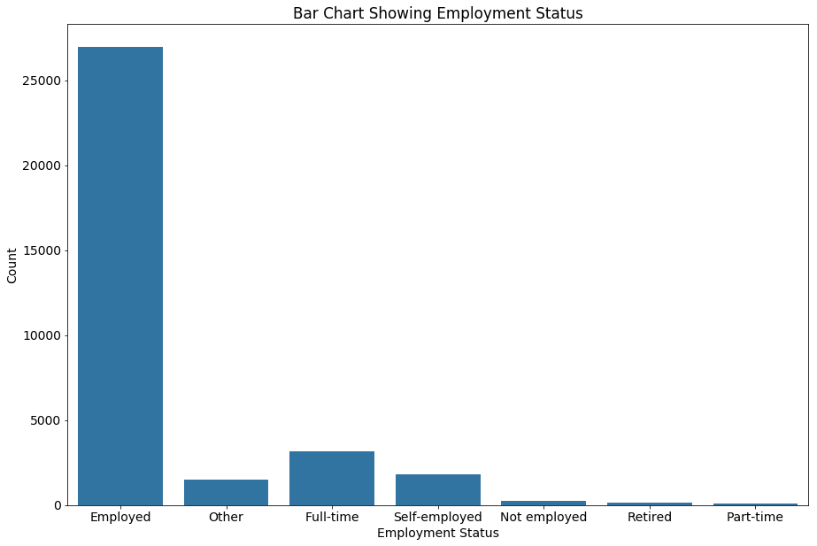

```python
sb.countplot(data=loan, x='EmploymentStatus', color=base_color);
#Labeling the axes
plt.title ('Bar Chart Showing Employment Status')
plt.xlabel('Employment Status')
plt.ylabel('Count')
```

### Observation 5

● Majority of the listings are indicted to be employed, people who are employed take more loans.

### Visualisation 6

[figure not shown]

```python
#bins2 = np.arange(0, loan.MonthlyLoanPayment.max()+50, 50)
plt.hist (loan.EmploymentStatusDuration.dropna().values, bins=20)
#Labeling the axes
plt.title ('Bar Chart Showing Borrower ')
plt.xlabel('Borrower State')
plt.ylabel('Count')

plt.axvline (np.mean(loan.EmploymentStatusDuration), color='green', linestyle='--' )
plt.show ()
```

### Observation 6

● The histogram is highly skewed to the right, showing that borrowers who have longer durations of employment take less loans

### Visualisation 7

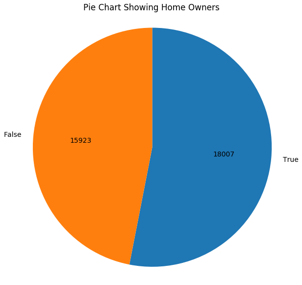

```python
mylabels=['True','False']
values=loan.IsBorrowerHomeowner.value_counts()
plt.pie (loan.IsBorrowerHomeowner.value_counts(), labels= mylabels, autopct= lambda x: '{:.0f}'.format(x*values.sum()/100), startangle = 90, counterclock = False)
plt.title('Pie Chart Showing Home Owners')
plt.axis('square')
plt.show ()
```

### Observation 7

● Home owners making more than half of the dataset take more loans

### Visualisation 8

I will be doing just one plot for Credit Score Range Lower and Credit Score Range Upper as they would have similar looking plots

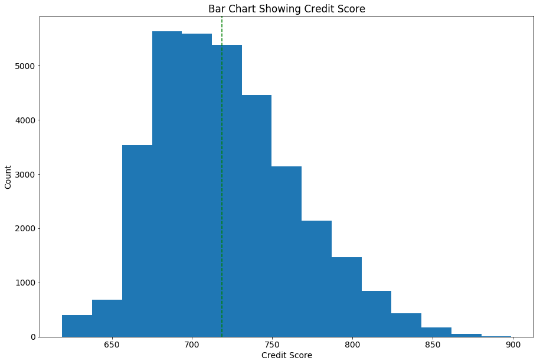

```python
plt.hist (loan.CreditScoreRangeUpper,bins=15)
#Labeling the axes
plt.title ('Bar Chart Showing Credit Score')
plt.xlabel('Credit Score')
plt.ylabel('Count')

plt.axvline (np.mean(loan.CreditScoreRangeUpper), color='green', linestyle='--' )
```

### Observation 8

● The histogram is skewed to the right showing that most borrowers have an upper credit score between 650 and 750

### Visualisation 10

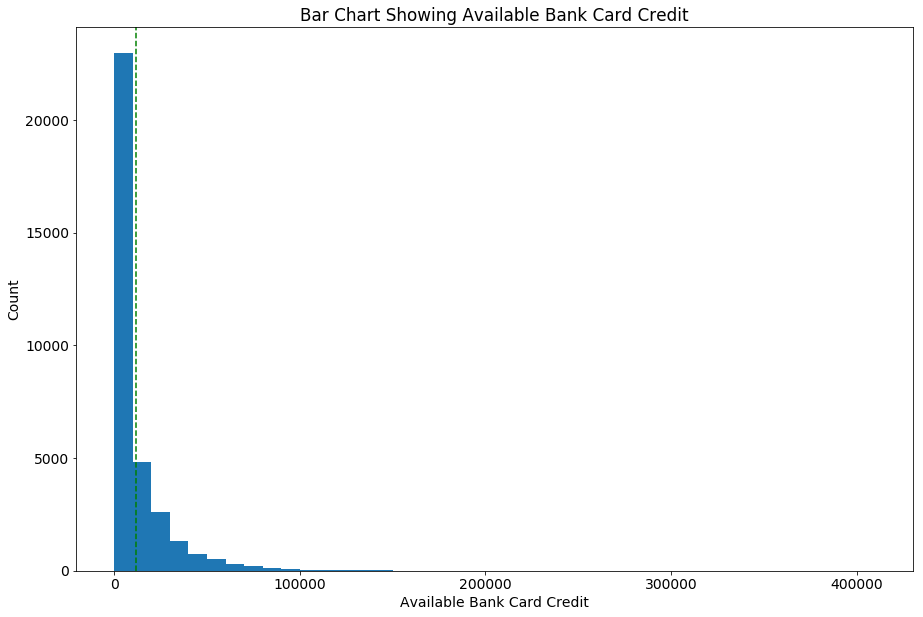

```python
bins = np.arange(0, loan.AvailableBankcardCredit.max()+10000, 10000)
plt.hist (loan.AvailableBankcardCredit,bins=bins)
#Labeling the axes
plt.title ('Bar Chart Showing Available Bank Card Credit')
plt.xlabel('Available Bank Card Credit')
plt.ylabel('Count')

plt.axvline (np.mean(loan.AvailableBankcardCredit), color='green', linestyle='--' )
plt.show ()
```

### Observation 10

● The histogram is highly skewed to the right showing that, most people have bank card credit below 5,000

### Visualisation 11

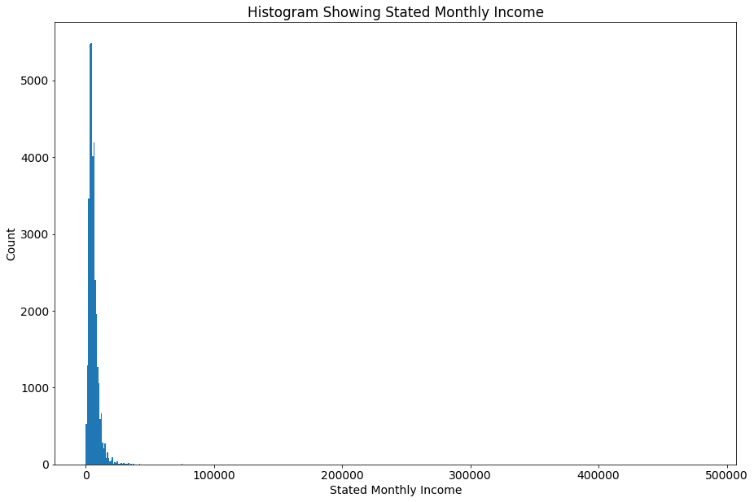

```python
plt.hist (loan.StatedMonthlyIncome, bins=500)
#Labeling the axes
plt.title ('Histogram Showing Stated Monthly Income')
plt.xlabel('Stated Monthly Income')
plt.ylabel('Count')
plt.show ()
```

### Observation 11

● The histogram is highly skewed to the right and not much can be seen from it but, most people stated to earn below 5,000 a month.

### Visualisation 12

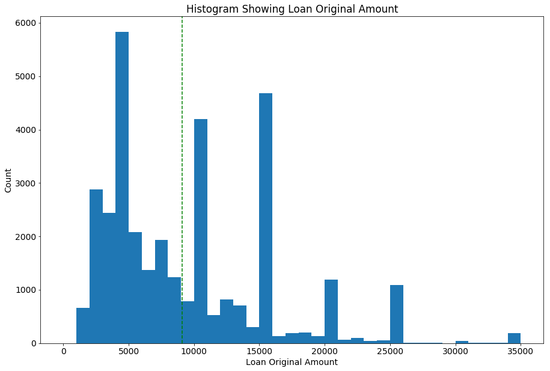

```python
bins3 = np.arange(0, loan.LoanOriginalAmount.max()+1000, 1000)
plt.hist (loan.LoanOriginalAmount, bins=bins3)
#Labeling the axes
plt.title ('Histogram Showing Loan Original Amount')
plt.xlabel('Loan Original Amount')
plt.ylabel('Count')

plt.axvline (np.mean(loan.LoanOriginalAmount), color='green', linestyle='--' )
plt.show ()
```

### Observation 12

The histogram is skewed to the right showing that: ● Most people take loans below 10000 but a substantial number of people also take loans of 15,000, 20,000 and 25,000.

● An outlying number of people take loans within the range of 30,000 to 35,000.

### Visualisation 13

```
Text(0.5,0,'Count')
```

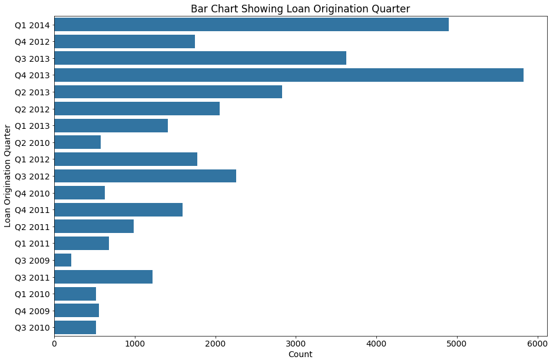

```python
sb.countplot(data=loan, y='LoanOriginationQuarter', color=base_color);

# Labeling the axes
plt.title ('Bar Chart Showing Loan Origination Quarter')
plt.ylabel('Loan Origination Quarter')
plt.xlabel('Count')
```

### Observation 13

● The fourth quarter of 2013 had the highest amount of loan listings while the third quarter of 2009 had the lowest amount of loan listings.

### Visualisation 14

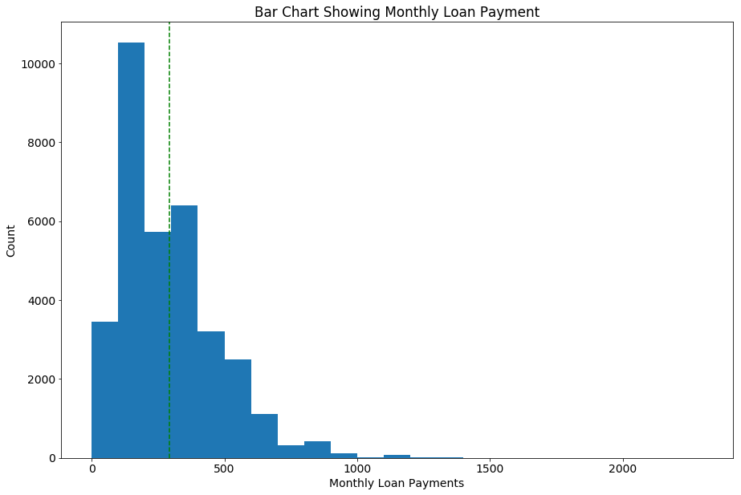

```python
bins4 = np.arange(0, loan.MonthlyLoanPayment.max()+100, 100)
plt.hist (loan.MonthlyLoanPayment,bins=bins4)
#Labeling the axes
plt.title ('Bar Chart Showing Monthly Loan Payment')
plt.xlabel('Monthly Loan Payments')
plt.ylabel('Count')
plt.axvline (np.mean(loan.MonthlyLoanPayment), color='green', linestyle='--' )
plt.show ()
```

### Observation 14

● The histogram is highly skewed to the right, showing most borrowers have monthly payments less than five hundred dollars

### Discuss the distribution(s) of your variable(s) of interest. Were there any unusual points? Did you need to perform any transformations?

The variable of interest LoanStatus, is a categorical variable separating the listings into 11 categories;

Current - the most populous category, having 22,605 listing showing people are yet to complete their loan payments but haven'tpast their due date

Completed - 7,938 listings of people who have completed their loan payments.

Chargedoff - 2,102 listings of people who left their debts unpaid.

Defaulted - 393 listings of people who have defaulted on their loan payments.

Past Due (1-15 days) - 314 listings of people who have defaulted on their loan payments by at most 15 days.

Past Due (31-60 days) - 159 listings of people who have defaulted on their loan payments by at most 60 days.

Past Due (91-120 days) - less than 200 listings of people who have defaulted on their loan payments by at most 120 days.

Past Due (61-90 days) - 110 listings of people who have defaulted on their loan payments by at most 90 days.

Past Due (16-30 days) - 97 listings of people who have defaulted on their loan payments by at most 30 days.

FinalPaymentInProgress - 86 people in process of completing their final payments.

Past Due (>120 days) - the least populous category showing 8 people who are 120 days past their loan due dates.

### Of the features you investigated, were there any unusual distributions? Did you perform any operations on the data to tidy, adjust, or change the form of the data? If so, why did you do this?

The only operation taken to change the dat, was changing ProsperScore datatype from float to int.

There were no particularly unusual distributions with the features investigated, a few outliers with MonthlyLoanPayments, AvailableBankcardCredit, StatedMonthlyIncome and LoanOriginalAmount.

## Bivariate Exploration

### Question

In line with my goal, to see the relationship select categorical variables have with Loan Status, how do these variables appear when compared or are plotted alongside Loan Status?.

### Visualisation 15

```
Text(0.5,1,'Clustered Bar Chart Showing Loan Status & Homeownership')
```

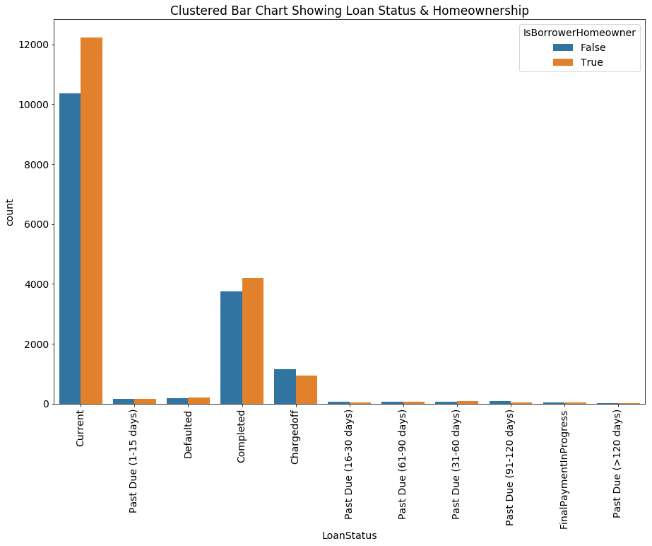

```python
sb.countplot(data = loan, x = 'LoanStatus', hue = 'IsBorrowerHomeowner')

plt.xticks(rotation=90);
plt.title ('Clustered Bar Chart Showing Loan Status & Homeownership')
```

### Observation 15

● More of those who had completed their loan payments are home owners, same goes for those who are listed under the status 'completed'.

● There are less home owners amongst those listed under 'chargedoff'.

### Visualisation 16

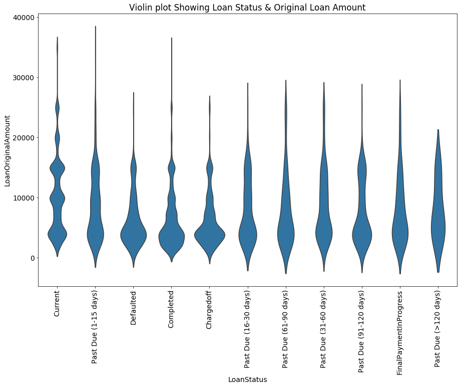

```python
sb.violinplot(data=loan, x='LoanStatus', y='LoanOriginalAmount', color=base_color, inner=None)
plt.xticks (rotation=90);
plt.title ('Violin plot Showing Loan Status & Original Loan Amount')
plt.figure(figsize=(8,4))
```

### Observation 16

● Those listed under the Loan Status 'current' majorly had loan original amounts range from 5,000, 10,000, 15,000 then 20,000 and 25,000. ● Those listed under the Loan Status 'completed' had loan original amounts below 40,000, streamlines down to about 15,000 then pools from about 5,000 and below.

● Most charged off loans are below 5,000.

● Those listed under the Loan Status 'defaulted' had loan original amounts from below 30,000 especially from 10,000 below.

● The other categories have similar shapes not going above 30,000 at concentrate around 5,000 asides 'Past Due (1-15 days)' which starts just below 40,000